# Pedigree caller on a ZEAL-structured cohort

- Show All Code
- Hide All Code
- View Source

Does family coupling beat per-individual calling at ZEAL’s scale and skim depth? — 82 donor founders, ~17 lines/founder, n ≈ 1394

Author

Fausto Rodríguez-Zapata

Published

July 16, 2026

**NoteDependency**

This notebook uses `nilHMM`’s `call_ancestry(caller = "pedigree")`. Until nilhmm **PR #10** (`feat/pedigree-counts-emission`) is merged to `main`, reproduce by installing `nilHMM` from that branch (`R CMD INSTALL` the branch working tree); the setup guard below fails loudly against an older build. Method: paper supplement Text S9 and `nilhmm/design/PEDIGREE_HMM.md`.

The count/geometric callers decode each individual’s chromosome independently; the `pedigree` caller instead couples a selfing family’s relatives by loopy belief propagation over the (pedigree × genome) grid (supplement Text S9). This notebook asks the honest question on a **ZEAL-structured** simulated cohort: at ZEAL’s scale (82 donor founders, ~17 lines per founder, ~1400 lines) and skim depth, does the coupling beat per-individual calling? The answer here is a **characterization, not a win** — see the Take.

## Setup

```r
suppressMessages({
  library(nilHMM) # simulate_family, simulate_counts, call_states, to_segments
  library(data.table)
  library(ggplot2)
})
stopifnot("pedigree" %in% eval(formals(nilHMM::call_states)$caller)) # guard: caller must be installed
set.seed(params$seed)

# Per-marker dosage accuracy of a call_states() table vs the simcross truth mosaic.
dosage_acc <- function(calls, truth) {
  kt <- paste(truth$name, truth$chr, truth$pos)
  ts <- truth$state[match(paste(calls$name, calls$chr, calls$pos), kt)]
  mean(calls$state == ts, na.rm = TRUE)
}
```

## 1. A ZEAL-matched cohort

```r
sim <- simulate_family(params$design,
  families = params$founders, sibs = params$lines_per_founder,
  chr = params$chr, n_markers = params$n_markers, seed = params$seed
)
truth <- sim$truth

data.table(
  quantity = c("total lines", "donor founders", "mean lines/founder"),
  `ZEAL (real)` = c("1439", "82", "17.1"),
  `simulated` = c(
    length(unique(truth$name)),
    length(unique(sim$pedigree$family)),
    round(length(unique(truth$name)) / length(unique(sim$pedigree$family)), 1)
  )
) |> knitr::kable()
```

| quantity | ZEAL (real) | simulated |
| --- | --- | --- |
| total lines | 1439 | 1394 |
| donor founders | 82 | 82 |
| mean lines/founder | 17.1 | 17 |

## 2. Accuracy versus sequencing depth

Degrade the same truth mosaic across a depth ladder bracketing ZEAL’s skim regime (~0.4×) and call three ways on the identical reads: two single-chain callers (`nnil`, `rtiger`) and the family-coupled `pedigree` caller.

```r
depths <- c(0.1, 0.2, 0.4, 0.8, 1.6, 3.2)
depth_res <- rbindlist(lapply(depths, function(d) {
  o <- simulate_counts(truth, depth = d, error = 0.01, seed = params$seed)
  o$cm <- truth$cm[match(paste(o$name, o$chr, o$pos), paste(truth$name, truth$chr, truth$pos))]
  data.table(
    depth    = d,
    zero_cov = mean((o$n_ref + o$n_alt) == 0),
    nnil     = dosage_acc(call_states(o, caller = "nnil", design = params$design, rrate = 1e-3), truth),
    rtiger   = dosage_acc(call_states(o, caller = "rtiger", design = params$design, rigidity = 3L), truth),
    pedigree = dosage_acc(call_states(o, caller = "pedigree", pedigree = sim$pedigree, design = params$design), truth)
  )
}))
knitr::kable(depth_res, digits = 3)
```

| depth | zero_cov | nnil | rtiger | pedigree |
| --- | --- | --- | --- | --- |
| 0.1 | 0.904 | 0.940 | 0.967 | 0.969 |
| 0.2 | 0.818 | 0.974 | 0.982 | 0.973 |
| 0.4 | 0.670 | 0.986 | 0.990 | 0.976 |
| 0.8 | 0.449 | 0.993 | 0.995 | 0.980 |
| 1.6 | 0.202 | 0.997 | 0.997 | 0.997 |
| 3.2 | 0.040 | 0.998 | 0.999 | 0.999 |

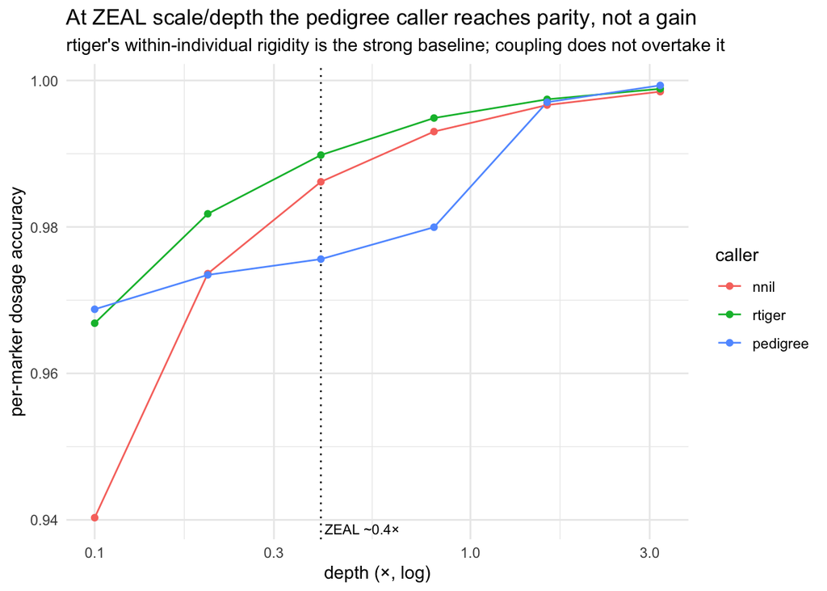

```r
ggplot(
  melt(depth_res[, .(depth, nnil, rtiger, pedigree)],
    id.vars = "depth",
    variable.name = "caller", value.name = "accuracy"
  ),
  aes(depth, accuracy, colour = caller)
) +
  geom_vline(xintercept = 0.4, linetype = "dotted") +
  annotate("text", x = 0.4, y = -Inf, label = " ZEAL ~0.4×", hjust = 0, vjust = -0.5, size = 3) +
  geom_line() +
  geom_point() +
  scale_x_log10() +
  labs(
    x = "depth (×, log)", y = "per-marker dosage accuracy",
    title = "At ZEAL scale/depth the pedigree caller reaches parity, not a gain",
    subtitle = "rtiger's within-individual rigidity is the strong baseline; coupling does not overtake it"
  ) +
  theme_minimal()
```

## 3. What the coupling *does* buy: full-grid missing-data fill

At skim depth a large fraction of markers carry no reads. The count emission emits flat there (`n = 0`) and the pedigree fills the state from relatives (Text S9.3): the caller leaves **no marker uncalled**. We score accuracy specifically on the zero-coverage markers at ZEAL’s ~0.4×.

```r
o <- simulate_counts(truth, depth = 0.4, error = 0.01, seed = params$seed)
o$cm <- truth$cm[match(paste(o$name, o$chr, o$pos), paste(truth$name, truth$chr, truth$pos))]
o$depth <- o$n_ref + o$n_alt
cp <- call_states(o, caller = "pedigree", pedigree = sim$pedigree, design = params$design)
zc <- o[o$depth == 0, c("name", "chr", "pos")]
kt <- paste(truth$name, truth$chr, truth$pos)
ts_z <- truth$state[match(paste(zc$name, zc$chr, zc$pos), kt)]
pz <- cp$state[match(paste(zc$name, zc$chr, zc$pos), paste(cp$name, cp$chr, cp$pos))]
cat(sprintf("zero-coverage markers at 0.4x: %.0f%% of the grid\n", 100 * nrow(zc) / nrow(o)))
```

```
zero-coverage markers at 0.4x: 67% of the grid
```

```r
cat(sprintf("pedigree calls left uncalled: %d\n", sum(is.na(pz))))
```

```
pedigree calls left uncalled: 0
```

```r
cat(sprintf("pedigree accuracy on the zero-coverage markers: %.3f\n", mean(pz == ts_z, na.rm = TRUE)))
```

```
pedigree accuracy on the zero-coverage markers: 0.975
```

## 4. Why parity, not a gain

The gap to `rtiger` is expected from the model, not a bug. The current kernel couples relatives with a **per-marker** selfing factor $T^{\mathrm{sib}}$, which drops *transmission linkage*: a parent transmits a donor **segment** as a coherent block, but the per-marker factor only pools siblings marker-by-marker (weak marginal pooling), not over the shared blocks they actually inherited (`nilhmm/design/PEDIGREE_HMM.md` §2). Meanwhile `rtiger` already captures block coherence *within* each individual through its rigidity prior — the strong baseline. Block-coherent *cross-sibling* pooling — the mechanism that would let the coupling overtake `rtiger` — needs the **phased copy-switch transmission kernel** (§18), deferred to a follow-up branch.

## Take

So the caller is validated as **correct and principled infrastructure** (depth-aware family coupling + the `refine_ancestry()` workflow + the foundation for the phased kernel), **not** as an accuracy improvement over `rtiger` on ZEAL-like data. The block-coherent gain is the goal of the phased copy-switch kernel (§18), a separate branch.